# ISTA 320 Data Visualization Challenge 7

Jacquie Kuru

Spring 2023

For this data viz challenge, you will be working with [patient satisfaction data from Kaggle](https://www.kaggle.com/vdimitrievska/patient-satisfaction-dataset)

# Data Wrangling

Read the data in and do any changes you deem necessary.

```r
# ENTER YOUR DATA WRANGLING CODE HERE ---------------------------------------------
patient_satisfaction_raw <- read_csv("datasetsatisfaction.csv")
#inspect data
patient_satisfaction_raw %>%
  head()
```

```
## # A tibble: 6 × 17
##   satisfaction…¹ Check…² Time …³ Admin…⁴ Hygie…⁵ Time …⁶ Quali…⁷ Speci…⁸ Commu…⁹
##            <dbl>   <dbl>   <dbl>   <dbl>   <dbl>   <dbl>   <dbl>   <dbl>   <dbl>
## 1              1       1       1       1       1       1       1       1       1
## 2              2       2       1       2       1       2       2       1       2
## 3              2       1       1       2       2       2       4       4       4
## 4              2       2       4       1       1       2       4       1       1
## 5              3       4       1       1       2       1       5       5       5
## 6              2       2       3       4       1       1       4       2       3
## # … with 8 more variables: `Exact diagnosis` <dbl>, `Modern equipment` <dbl>,
## #   `friendly health care workers` <dbl>, `lab services` <dbl>,
## #   `avaliablity of drugs` <dbl>, `waiting rooms` <dbl>,
## #   `hospital rooms quality` <dbl>, `parking, playing rooms, caffes` <dbl>, and
## #   abbreviated variable names ¹`satisfaction in RM`, ²`Check up appointment`,
## #   ³`Time waiting`, ⁴`Admin procedures`, ⁵`Hygiene and cleaning`,
## #   ⁶`Time of appointment`, ⁷`Quality/experience dr.`, …
```

```r
#Problem is that every question is its own column - these questions are values of the variable question_item! Need to be pivot_longer() into new dataframe.

patient_satisfaction_tidy <- patient_satisfaction_raw %>%
  pivot_longer(cols = `satisfaction in RM`:`parking, playing rooms, caffes`,
               names_to = "question_item",
               values_to = "response")

#inspect tidy data
patient_satisfaction_tidy %>%
  head()
```

```
## # A tibble: 6 × 2
##   question_item        response
##   <chr>                   <dbl>
## 1 satisfaction in RM          1
## 2 Check up appointment        1
## 3 Time waiting                1
## 4 Admin procedures            1
## 5 Hygiene and cleaning        1
## 6 Time of appointment         1
```

```r
#Create specialized data frames ---------------------------------------------------


#### COUNT()
patient_satisfaction_count <- patient_satisfaction_tidy %>%
  count(question_item,response) %>%
  drop_na() %>%
  mutate(n = ifelse(response >2, n ,-n))

#inspect dataframe
patient_satisfaction_count
```

```
## # A tibble: 83 × 3
##    question_item        response     n
##    <chr>                   <dbl> <int>
##  1 Admin procedures            1  -135
##  2 Admin procedures            2   -97
##  3 Admin procedures            3    86
##  4 Admin procedures            4    84
##  5 Admin procedures            5    50
##  6 Check up appointment        1  -159
##  7 Check up appointment        2   -63
##  8 Check up appointment        3    78
##  9 Check up appointment        4    92
## 10 Check up appointment        5    60
## # … with 73 more rows
```

```r
#### PERCENTAGE()------------------------------------------------------------------
patient_satisfaction_percentage <- patient_satisfaction_tidy %>%
  filter(!is.na(response)) %>%
  group_by(question_item,response) %>%
  summarize(n = n()) %>%
  mutate(total = sum(n),
         percentage = n/total,
         response = factor(response))
#inspect dataframe
patient_satisfaction_percentage
```

```
## # A tibble: 83 × 5
## # Groups:   question_item [17]
##    question_item        response     n total percentage
##    <chr>                <fct>    <int> <int>      <dbl>
##  1 Admin procedures     1          135   452      0.299
##  2 Admin procedures     2           97   452      0.215
##  3 Admin procedures     3           86   452      0.190
##  4 Admin procedures     4           84   452      0.186
##  5 Admin procedures     5           50   452      0.111
##  6 Check up appointment 1          159   452      0.352
##  7 Check up appointment 2           63   452      0.139
##  8 Check up appointment 3           78   452      0.173
##  9 Check up appointment 4           92   452      0.204
## 10 Check up appointment 5           60   452      0.133
## # … with 73 more rows
```

I will consider this section complete if you are able to successfully read and transform the data.

# Data Visualization

> Questions: What is the distribution of responses across different aspects of the service provided? Which service shows higher satisfaction? Which shows lower satisfaction?

Draw two (2) different plots to answer these questions. I will consider this completed if you are able to interpret your plots in a way to answer the three questions above.

**BAR PLOT: Response Total Count**

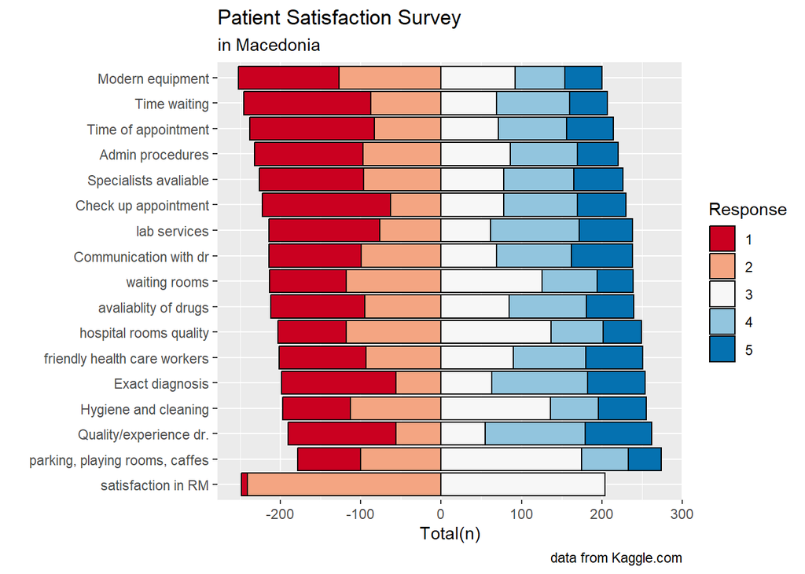

```r
patient_satisfaction_count %>%
  ggplot(aes(x = n,
             y = reorder(question_item,-n),
             fill=factor(response)),
         colour = "black")+
  geom_col(data = patient_satisfaction_count %>% filter( n > 0),
           position = position_stack(reverse = TRUE),
           color = "black",
           size = 0.5) +
  geom_col(data = patient_satisfaction_count %>% filter( n < 1),
           position = position_stack(reverse = FALSE),
           color="black",
           size = 0.5) +
  scale_fill_manual(values = brewer.pal(5, "RdBu")) +
  theme_grey()+
  labs(x = "Total(n)",
       y= "",
       fill = "Response",
       title = "Patient Satisfaction Survey",
       subtitle = "in Macedonia",
       caption = "data from Kaggle.com"
  )
```

**BAR PLOT: Distribution of Responses**

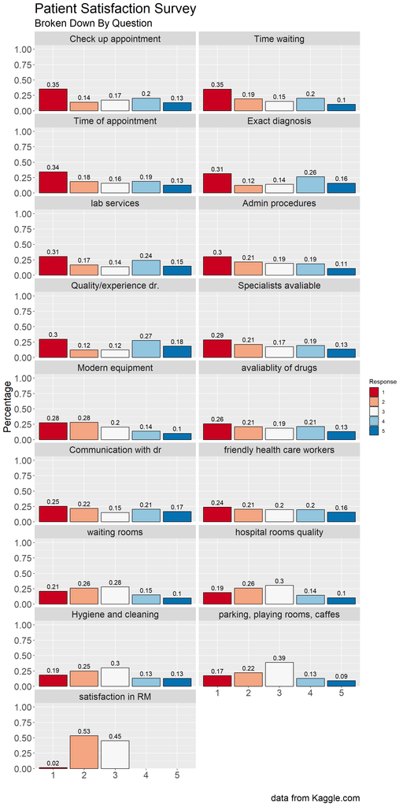

```r
patient_satisfaction_percentage %>%
  # facet_arrange arranges all subplots by percentage of response==1
  mutate(facet_arrange = ifelse(response==1,percentage,0)) %>%
  ggplot(aes(x=response,
         y=percentage,
         fill=response,))+
  geom_col(color = "black", size = 0.5)+
  geom_text(aes(label=round(percentage,2)),
            colour = 'black',
            fontface = "plain",
            size = 4,
            vjust = -0.5,
            position = position_stack(vjust = 1))+
  scale_fill_manual(values = brewer.pal(5, "RdBu")) +
  scale_y_continuous(expand = expansion(mult = c(0,1)))+
  facet_wrap(facets = ~reorder(question_item,-facet_arrange),ncol=2)+
  theme_grey()+
  labs(x="",
       y = "Percentage",
       fill = "Response",
       title="Patient Satisfaction Survey",
       subtitle= "Broken Down By Question",
       caption = "data from Kaggle.com")+
  theme(axis.text = element_text(size = 16),
        axis.title = element_text(size = 18),
        strip.text = element_text(size = 16),
        plot.title = element_text(size = 24),
        plot.subtitle = element_text(size = 18),
        plot.caption = element_text(size = 16),
        strip.placement = "outside"
  )
```

## Further exploration….

```r
patient_satisfaction_condensed <- patient_satisfaction_percentage %>%
  mutate(response = as.numeric(response)) %>%
  mutate(ranking = case_when(response <3 ~"bad",
                             response >3 ~"good",
                             response == 3~"neutral"))

patient_satisfaction_condensed <- patient_satisfaction_condensed %>%
  group_by(question_item,ranking) %>%
  summarize(percent = sum(percentage))
```

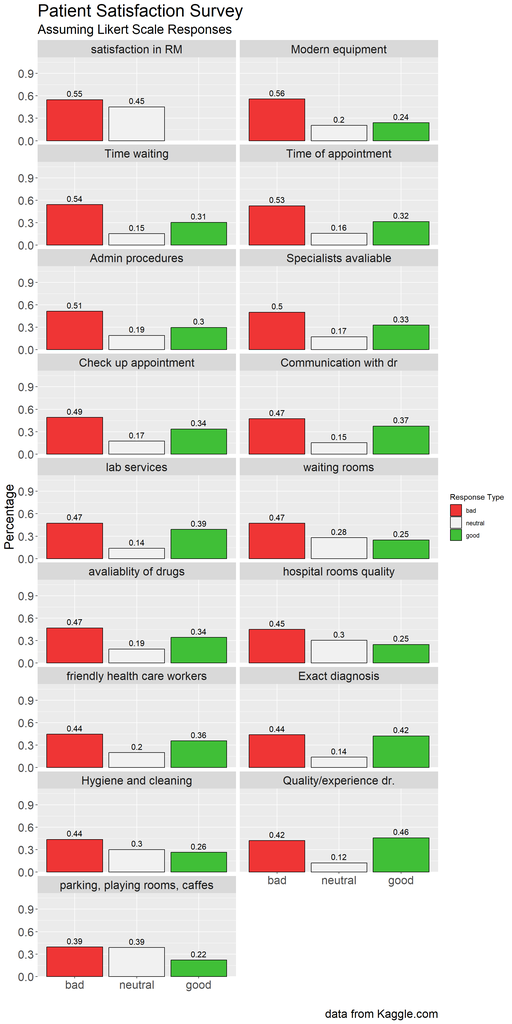

```r
patient_satisfaction_condensed %>%
  # facet_arrange arranges all subplots by percentage of response==1
  mutate(ranking_arrange = ifelse(ranking=="bad",percent,0)) %>%
  # explicit ordering of x axis
  mutate(ranking = factor(ranking, levels = c("bad", "neutral", "good"))) %>%
  ggplot(aes(x= ranking,
         y=percent,
         fill=ranking,))+
  geom_col(color = "black", size = 0.5)+
  geom_text(aes(label=round(percent,2)),
            colour = 'black',
            fontface = "plain",
            size = 4,
            vjust = -0.5,
            position = position_stack(vjust = 1))+
  scale_fill_manual(values = c("#EF3535","#F1F1F1","#40BF37")) +
  scale_y_continuous(expand = expansion(mult = c(0,1)))+
  facet_wrap(facets = ~reorder(question_item,-ranking_arrange),ncol=2)+
  theme_grey()+
  labs(x='',
       y = "Percentage",
       fill = "Response Type",
       title="Patient Satisfaction Survey",
       subtitle = "Assuming Likert Scale Responses",
       caption = "data from Kaggle.com") +
  theme(axis.text = element_text(size = 16),
        axis.title = element_text(size = 18),
        strip.text = element_text(size = 16),
        plot.title = element_text(size = 24),
        plot.subtitle = element_text(size = 18),
        plot.caption = element_text(size = 16),
        strip.placement = "outside"
  )
```

ENTER YOUR INTERPRETATION TO THE PLOT YOU CREATED HERE

> What is the distribution of responses across different aspects of the service provided? Which service shows higher satisfaction? Which shows lower satisfaction?

**Q1)** For the majority of questions, the distribution has all response types recognized, with responses of 5 being the rarest. The only question that does not have a response type of 5, or even 4, is the last service question on graph 1: `Satisfication in RM.`

**Q2 & Q3)** If only using graph 1, it would appear that `Satisfication in RM` would have the highest level of satisfaction and `Modern equipment` would have the lowest. However, looking at graph 2, which is the response type percentage breakdown for each question, I highly doubt `Satisfaction in RM` has the highest level of satisfaction - it didn’t have a single 4 or 5 response!

Looking at the data again, we see that all responses are a number from 1-5. This highly suggests the use of a Likert scale. Additionally, this is an odd number scale, meaning the middle number, 3, is mostly like interpreted as neutral. Assuming these details, I created a third graph condensing the response types into three groups: “bad (response < 3)”, “neutral (response == 3)”, and “good (response > 3).